# **Who’s Buying Bikes?**

Gary Rauco

08/08/2021

After a year and a half of global pandemic, and not being able to visit any gym, I decided to take out my old bicycle, and got to wondering who is still buying bikes in the world today?

When we are more focused on the environment than ever, and with peoples trends shifting what is the current bike demographic look like? This research is useful not only to determine how to better cater the bicycle market to current users, but also potentially find ways to broaden the market for bicycle ownership.We will be using the *Bike Buyers 1000* dataset to assist in our research.

- https://www.kaggle.com/heeraldedhia/bike-buyers

Before we begin any analysis, we have to format our data, and even before that we have to tell R what packages we will be using.

```r
library(tidyverse)
library(gridExtra)
library(knitr)
library(kableExtra)
library(ggthemes)
library(stargazer)
library(mosaicData)
```

To make our lives easier down the road, we will also include this custom MakeTable() function in order to output some nice looking tables!

```r
MakeTable <- function(df){
  kable(df,'html',booktabs=TRUE) %>%
    kable_styling(bootstrap_options = c("hover","responsive"),
                  font_size = 12)
}
```

We finally can now load our dataset into R.

```r
BikeBuyers <- read.csv('C:/Users/garyp/OneDrive/Case Studies/Bike_Report_files/bike_buyers.csv',
                       fileEncoding='UTF-8-BOM')
BikeBuyers <- na.omit(BikeBuyers)
```

```r
MakeTable(head(BikeBuyers))
```

| ID | Marital.Status | Gender | Income | Children | Education | Occupation | Home.Owner | Cars | Commute.Distance | Region | Age | Purchased.Bike |
| --- | --- | --- | --- | --- | --- | --- | --- | --- | --- | --- | --- | --- |
| 12496 | Married | Female | 40000 | 1 | Bachelors | Skilled Manual | Yes | 0 | 0-1 Miles | Europe | 42 | No |
| 24107 | Married | Male | 30000 | 3 | Partial College | Clerical | Yes | 1 | 0-1 Miles | Europe | 43 | No |
| 14177 | Married | Male | 80000 | 5 | Partial College | Professional | No | 2 | 2-5 Miles | Europe | 60 | No |
| 24381 | Single |  | 70000 | 0 | Bachelors | Professional | Yes | 1 | 5-10 Miles | Pacific | 41 | Yes |
| 25597 | Single | Male | 30000 | 0 | Bachelors | Clerical | No | 0 | 0-1 Miles | Europe | 36 | Yes |
| 13507 | Married | Female | 10000 | 2 | Partial College | Manual | Yes | 0 | 1-2 Miles | Europe | 50 | No |

```r
MakeTable(summary(BikeBuyers))
```

|  | ID | Marital.Status | Gender | Income | Children | Education | Occupation | Home.Owner | Cars | Commute.Distance | Region | Age | Purchased.Bike |
| --- | --- | --- | --- | --- | --- | --- | --- | --- | --- | --- | --- | --- | --- |
|  | Min. :11000 | Length:971 | Length:971 | Min. : 10000 | Min. :0.000 | Length:971 | Length:971 | Length:971 | Min. :0.000 | Length:971 | Length:971 | Min. :25.00 | Length:971 |
|  | 1st Qu.:15346 | Class :character | Class :character | 1st Qu.: 30000 | 1st Qu.:0.000 | Class :character | Class :character | Class :character | 1st Qu.:1.000 | Class :character | Class :character | 1st Qu.:35.00 | Class :character |
|  | Median :19812 | Mode :character | Mode :character | Median : 60000 | Median :2.000 | Mode :character | Mode :character | Mode :character | Median :1.000 | Mode :character | Mode :character | Median :43.00 | Mode :character |
|  | Mean :20014 | NA | NA | Mean : 56179 | Mean :1.903 | NA | NA | NA | Mean :1.454 | NA | NA | Mean :44.21 | NA |
|  | 3rd Qu.:24549 | NA | NA | 3rd Qu.: 70000 | 3rd Qu.:3.000 | NA | NA | NA | 3rd Qu.:2.000 | NA | NA | 3rd Qu.:52.00 | NA |
|  | Max. :29447 | NA | NA | Max. :170000 | Max. :5.000 | NA | NA | NA | Max. :4.000 | NA | NA | Max. :89.00 | NA |

We can see most of our dataset variables are categorical. There are only a handful missing (NA) values, so we can reasonably remove these to move forward with initial exploration.

```r
MakeTable(summary(BikeBuyers))
```

|  | ID | Marital.Status | Gender | Income | Children | Education | Occupation | Home.Owner | Cars | Commute.Distance | Region | Age | Purchased.Bike |
| --- | --- | --- | --- | --- | --- | --- | --- | --- | --- | --- | --- | --- | --- |
|  | Min. :11000 | : 5 | : 10 | Min. : 10000 | 0:270 | Partial High School: 73 | Clerical :172 | : 4 | Min. :0.000 | 0-1 Miles :350 | Europe :288 | Min. :25.00 | No :507 |
|  | 1st Qu.:15346 | Married:525 | Female:477 | 1st Qu.: 30000 | 1:166 | High School :174 | Management :169 | No :306 | 1st Qu.:1.000 | 1-2 Miles :165 | North America:495 | 1st Qu.:35.00 | Yes:464 |
|  | Median :19812 | Single :441 | Male :484 | Median : 60000 | 2:203 | Partial College :257 | Manual :112 | Yes:661 | Median :1.000 | 2-5 Miles :160 | Pacific :188 | Median :43.00 | NA |
|  | Mean :20014 | NA | NA | Mean : 56179 | 3:130 | Bachelors :301 | Professional :270 | NA | Mean :1.454 | 5-10 Miles:187 | NA | Mean :44.21 | NA |
|  | 3rd Qu.:24549 | NA | NA | 3rd Qu.: 70000 | 4:124 | Graduate Degree :166 | Skilled Manual:248 | NA | 3rd Qu.:2.000 | 10+ Miles :109 | NA | 3rd Qu.:52.00 | NA |
|  | Max. :29447 | NA | NA | Max. :170000 | 5: 78 | NA | NA | NA | Max. :4.000 | NA | NA | Max. :89.00 | NA |

```r
RegionTable <-
  BikeBuyers %>%
  group_by(Region) %>%
    summarize(Count=n(),Percent=n()/dim(BikeBuyers)[1])
```

We want to discover what kinds of people are in the market for buying bikes, which this dataset provides us in the *‘Purchased Bike’* field. We can start by making a few graphs to get a feel for any trends that immediately stick out. Since our data is categorical, it might make more sense to look at some of these trends in terms of percentage of the group, instead of a standard bar chart.

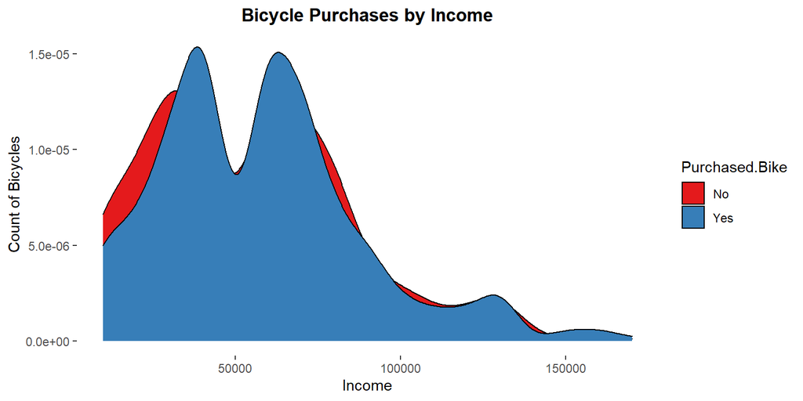

We can see that for the most part, income doesnt have much of an effect on Bike Purchases, there seems to be less overall interest from roughly $45,000 and below, but otherwise bike purchasing habits seem unchanged across all income levels.

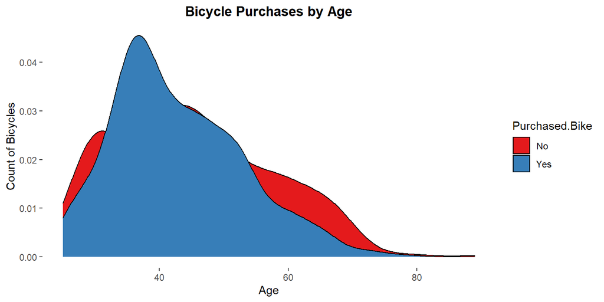

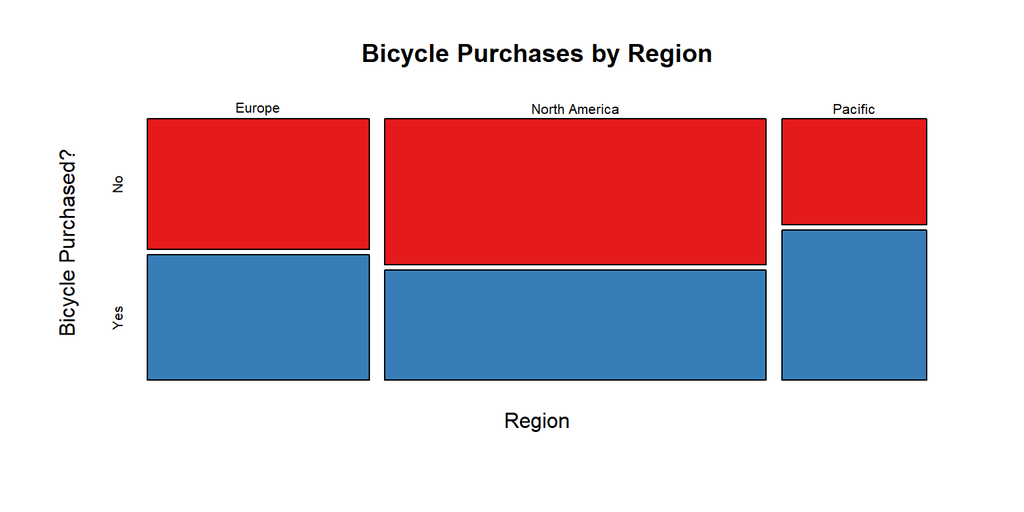

Region shows us proportionally that North America buys less bikes than other regions, and that the Pacific region buys more bikes proportionally. Europe is just about 50/50 on bicycle purchases.

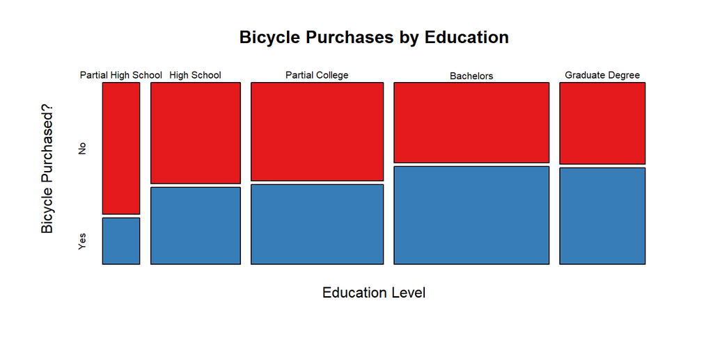

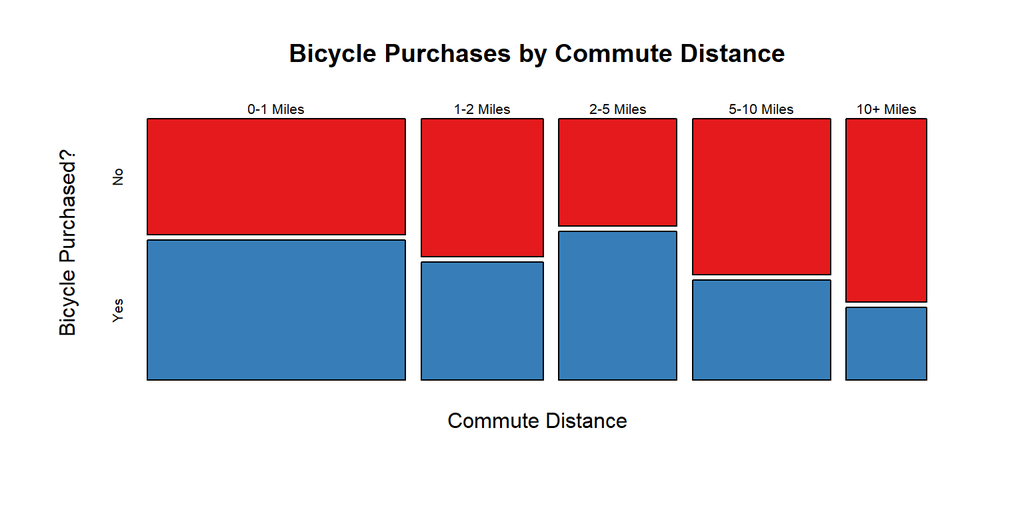

Now that we have a good understanding of what we might expect are important bicycle purchasing factors, lets try and use some more advanced methods to test our hypothesis!

We want to determine what variables affect a persons decision to purchase a bicycle. Since our response variable is a simple Yes/No outcome, it makes sense to use logistic regression! We identified: * Age * Region * Education * Commute Distance As having some type of a trend so lets start with these.

```r
BikeReg <- glm(Purchased.Bike~Age+Region+Education+Commute.Distance,
               family='binomial',
               data=BikeBuyers)
```

|  | *Dependent variable:* |
| --- | --- |
|  | Purchased.Bike |
| Age | -0.016*** (0.006) |
| RegionNorth America | -0.165 (0.169) |
| RegionPacific | 0.607*** (0.216) |
| EducationHigh School | 0.849*** (0.316) |
| EducationPartial College | 0.794*** (0.301) |
| EducationBachelors | 1.180*** (0.304) |
| EducationGraduate Degree | 1.176*** (0.324) |
| Commute.Distance1-2 Miles | -0.141 (0.207) |
| Commute.Distance2-5 Miles | 0.206 (0.204) |
| Commute.Distance5-10 Miles | -0.527** (0.218) |
| Commute.Distance10+ Miles | -1.064*** (0.262) |
| Constant | -0.150 (0.374) |
| Observations | 971 |
| Log Likelihood | -631.448 |
| Akaike Inf. Crit. | 1,286.896 |
| *Note:* | p<0.1; p<0.05; p<0.01 |

We should take our coefficients and convert them to a more readable format, since our regression table shows our coefficients as log odds, instead of odds, which we can easily convert.

```r
MakeTable(exp(BikeReg$coefficients))
```

|  | x |
| --- | --- |
| (Intercept) | 0.8604669 |
| Age | 0.9841355 |
| RegionNorth America | 0.8482082 |
| RegionPacific | 1.8342055 |
| EducationHigh School | 2.3378013 |
| EducationPartial College | 2.2126441 |
| EducationBachelors | 3.2537387 |
| EducationGraduate Degree | 3.2410588 |
| Commute.Distance1-2 Miles | 0.8681140 |
| Commute.Distance2-5 Miles | 1.2282371 |
| Commute.Distance5-10 Miles | 0.5901237 |
| Commute.Distance10+ Miles | 0.3450486 |